# Tugas Praktikum 3 Analisis Regresi

# DATA

## Pembacaan Data

```r
library(dplyr)
library(knitr)
# Path file
user_path <- "C:/Users/HP/Downloads/Tugas Individu Anreg 2_Arifatu Dzikra - Data Statistik BPS Terbaru dan Relevan.csv"

# Membaca data (base R agar aman saat knit)
dt_full <- read.csv(user_path, stringsAsFactors = FALSE)

# Melihat nama kolom
names(dt_full)
```

```
##  [1] "No"                "Provinsi"          "Y..Kemiskinan..."
##  [4] "X1..IKLH."         "X2..IPM."          "X3..TPT..."
##  [7] "X4..PDRB.Ribu.Rp." "X5..Gini.Ratio."   "X"
## [10] "X.1"               "X.2"               "X.3"
## [13] "X.4"
```

# MEMILIH VARIABEL

## Menentukan X (IPM) dan Y (Persentase Kemiskinan)

```r
# Deteksi otomatis kolom
col_x <- grep("ipm|indeks pembangunan", names(dt_full), ignore.case = TRUE, value = TRUE)[1]
col_y <- grep("kemiskin|persentase", names(dt_full), ignore.case = TRUE, value = TRUE)[1]

# Mapping variabel
dt <- dt_full %>%
  mutate(
    X = as.numeric(.data[[col_x]]),
    Y = as.numeric(.data[[col_y]])
  ) %>%
  filter(!is.na(X) & !is.na(Y))

n <- nrow(dt)

cat("Jumlah amatan =", n, "\n")
```

```
## Jumlah amatan = 34
```

# STATISTIK DESKRIPTIF

## Ringkasan IPM dan Persentase Kemiskinan

```r
x <- dt$X
y <- dt$Y

data.frame(
  Variabel = c("IPM","Persentase Kemiskinan"),
  Mean = c(mean(x), mean(y)),
  SD = c(sd(x), sd(y)),
  n = c(n,n)
)
```

```
##                Variabel     Mean       SD  n
## 1                   IPM 73.68235 3.743425 34
## 2 Persentase Kemiskinan 10.11118 5.236007 34
```

# MODEL REGRESI LINEAR

## Estimasi Parameter

```r
model <- lm(y ~ x, data = dt)
summary(model)
```

```
##
## Call:
## lm(formula = y ~ x, data = dt)
##
## Residuals:
##     Min      1Q  Median      3Q     Max
## -6.4766 -2.3079  0.0858  2.6532  8.0208
##
## Coefficients:
##             Estimate Std. Error t value Pr(>|t|)
## (Intercept)  80.6531    13.2989   6.065 9.00e-07 ***
## x            -0.9574     0.1803  -5.311 8.04e-06 ***
## ---
## Signif. codes:  0 '***' 0.001 '**' 0.01 '*' 0.05 '.' 0.1 ' ' 1
##
## Residual standard error: 3.876 on 32 degrees of freedom
## Multiple R-squared:  0.4685, Adjusted R-squared:  0.4519
## F-statistic: 28.21 on 1 and 32 DF,  p-value: 8.039e-06
```

```r
b0 <- coef(model)[1]
b1 <- coef(model)[2]

cat("Persamaan regresi:\n")
```

```
## Persamaan regresi:
```

```r
cat("Y_duga =", round(b0,6), "+", round(b1,6), "X\n")
```

```
## Y_duga = 80.65313 + -0.957379 X
```

# Anova

```r
anova_model <- anova(model)
anova_model
```

```
## Analysis of Variance Table
##
## Response: y
##           Df Sum Sq Mean Sq F value    Pr(>F)
## x          1 423.86  423.86  28.206 8.039e-06 ***
## Residuals 32 480.86   15.03
## ---
## Signif. codes:  0 '***' 0.001 '**' 0.01 '*' 0.05 '.' 0.1 ' ' 1
```

# PENGURAIAN KERAGAMAN

## Scatterplot dan Garis Regresi

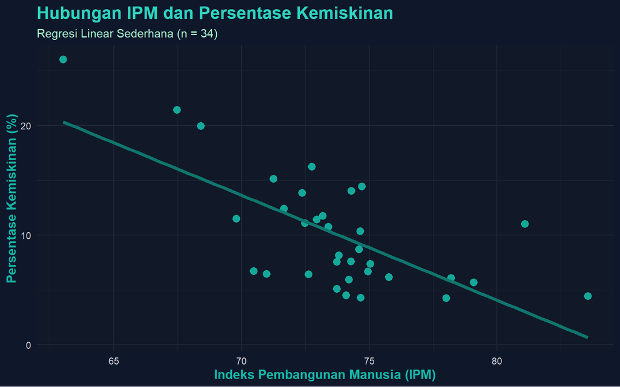

```r
library(ggplot2)

ggplot(dt, aes(x = X, y = Y)) +

  # Titik scatter
  geom_point(color = "#14b8a6", size = 3, alpha = 0.9) +

  # Garis regresi
  geom_smooth(method = "lm", se = FALSE, color = "#0f766e", linewidth = 1.5) +

  # Judul dan label
  labs(
    title = "Hubungan IPM dan Persentase Kemiskinan",
    subtitle = "Regresi Linear Sederhana (n = 34)",
    x = "Indeks Pembangunan Manusia (IPM)",
    y = "Persentase Kemiskinan (%)"
  ) +

  # Tema gelap custom
  theme_minimal() +
  theme(
    plot.background = element_rect(fill = "#0f172a", color = NA),
    panel.background = element_rect(fill = "#111827", color = NA),
    panel.grid.major = element_line(color = "#1f2937"),
    panel.grid.minor = element_line(color = "#1f2937"),
    text = element_text(color = "#e5e7eb"),
    axis.text = element_text(color = "#d1d5db"),
    axis.title = element_text(color = "#14b8a6", size = 12, face = "bold"),
    plot.title = element_text(color = "#2dd4bf", size = 16, face = "bold"),
    plot.subtitle = element_text(color = "#a7f3d0")
  )
```

## JKR, JKG, JKT, KTG dan Galat Baku

```r
yhat <- predict(model)
ybar <- mean(y)

JKR <- sum((yhat - ybar)^2)
JKG <- sum((y - yhat)^2)
JKT <- sum((y - ybar)^2)

KTG <- JKG/(n-2)
Se  <- sqrt(KTG)

data.frame(
  Komponen = c("JKR","JKG","JKT","KTG","Se"),
  Nilai = c(JKR,JKG,JKT,KTG,Se)
)
```

```
##   Komponen      Nilai
## 1      JKR 423.857808
## 2      JKG 480.862545
## 3      JKT 904.720353
## 4      KTG  15.026955
## 5       Se   3.876462
```

## KOEFISIEN DETERMINASI

```r
R2 <- summary(model)$r.squared
AdjR2 <- summary(model)$adj.r.squared

cat("R-squared =", R2, "\n")
```

```
## R-squared = 0.4684959
```

```r
cat("Adjusted R-squared =", AdjR2, "\n")
```

```
## Adjusted R-squared = 0.4518864
```

# UJI HIPOTESIS PARAMETER

## Uji t untuk β0 dan β1

```r
se_b1 <- summary(model)$coefficients[2,2]
se_b0 <- summary(model)$coefficients[1,2]

t_b1 <- b1/se_b1
t_b0 <- b0/se_b0

p_b1 <- summary(model)$coefficients[2,4]
p_b0 <- summary(model)$coefficients[1,4]

alpha <- 0.05
t_tabel <- qt(0.975, df=n-2)

data.frame(
  Parameter=c("b0","b1"),
  Estimate=c(b0,b1),
  SE=c(se_b0,se_b1),
  t_hitung=c(t_b0,t_b1),
  p_value=c(p_b0,p_b1),
  t_tabel=t_tabel
)
```

```
##             Parameter   Estimate         SE  t_hitung      p_value  t_tabel
## (Intercept)        b0 80.6531287 13.2989143  6.064640 9.003332e-07 2.036933
## x                  b1 -0.9573792  0.1802642 -5.310979 8.039419e-06 2.036933
```

# SELANG KEPERCAYAAN PARAMETER

## Interval 95%

```r
CI_b0 <- b0 + c(-1,1)*t_tabel*se_b0
CI_b1 <- b1 + c(-1,1)*t_tabel*se_b1

data.frame(
  Parameter=c("b0","b1"),
  Lower=c(CI_b0[1],CI_b1[1]),
  Upper=c(CI_b0[2],CI_b1[2])
)
```

```
##   Parameter     Lower       Upper
## 1        b0 53.564127 107.7421308
## 2        b1 -1.324565  -0.5901931
```

# PREDIKSI

## Selang Kepercayaan Rataan dan Selang Prediksi Individu

```r
pred_conf <- predict(model, interval="confidence")
pred_pred <- predict(model, interval="prediction")
head(data.frame(
  X=x,
  Y=y,
  Y_hat=pred_conf[,1],
  CI_Lower=pred_conf[,2],
  CI_Upper=pred_conf[,3],
  PI_Lower=pred_pred[,2],
  PI_Upper=pred_pred[,3]
))
```

```
##       X     Y     Y_hat CI_Lower CI_Upper  PI_Lower PI_Upper
## 1 74.70 14.45  9.136902 7.732125 10.54168 1.1168214 17.15698
## 2 73.80  8.15  9.998544 8.643686 11.35340 1.9870557 18.01003
## 3 74.20  5.95  9.615592 8.248149 10.98304 1.6019661 17.62922
## 4 74.95  6.68  8.897558 7.465626 10.32949 0.8726758 16.92244
## 5 73.73  7.58 10.065560 8.711278 11.41984 2.0541696 18.07695
## 6 73.18 11.78 10.592119 9.225445 11.95879 2.5786241 18.60561
```

# INTERPRETASI HASIL REGRESI

Berdasarkan hasil estimasi diperoleh persamaan regresi:

Y_duga = b0 + b1 X

Koefisien slope (b1) menunjukkan perubahan rata-rata persentase kemiskinan untuk setiap kenaikan satu satuan IPM.

Jika p-value b1 < 0,05 maka terdapat bukti statistik bahwa IPM berpengaruh signifikan terhadap persentase kemiskinan pada taraf nyata 5%. Jika koefisien bernilai negatif maka peningkatan IPM menurunkan tingkat kemiskinan; jika bernilai positif maka peningkatan IPM meningkatkan tingkat kemiskinan.

Nilai R² menunjukkan proporsi variasi persentase kemiskinan yang dapat dijelaskan oleh IPM. Semakin besar R², semakin besar kemampuan model dalam menjelaskan variasi data.

KTG dan Se merepresentasikan ragam dan simpangan baku galat model. Nilai yang kecil menunjukkan model memiliki kesalahan prediksi yang relatif kecil.

Selang kepercayaan parameter memberikan rentang nilai yang diyakini memuat parameter populasi dengan tingkat kepercayaan 95%.

Selang kepercayaan rataan menunjukkan ketelitian dugaan nilai rata-rata respon, sedangkan selang prediksi individu menunjukkan rentang kemungkinan nilai observasi baru pada tingkat IPM tertentu.

Secara keseluruhan, model regresi linear ini menggambarkan hubungan linier antara IPM dan persentase kemiskinan pada 34 amatan data provinsi, dengan signifikansi dan kekuatan hubungan ditentukan oleh nilai p-value dan R² yang diperoleh dari hasil estimasi.